# R Notebook

Muravetska Yaryna, Kantsir Solomia D.A.W.N. vs Covid-19

```r
library('corrplot')
library(readxl)
library("sjPlot")
library(forecast)
library(ggplot2)
library(GGally)
library(forecast)
library(dynlm)
```

```r
#we've taken dataset for daily coronavirus deaths and confirmed cases
corona <- read_excel("project_data.xlsx")
deaths <- corona$Deaths
cases <- corona$Confirmed
d <- corona$date

#stocks' prices for same dates
nflx <- read.csv(file = 'NFLX.csv')$Close
dpz <- read.csv(file = 'DPZ.csv')$Close
atvi1 <- read.csv(file = 'ATVI.csv')$Close

# deleting NaNs from atvi data
atvi <- c()
for (el in atvi1){
  if (el != 'null'){
    atvi <- append(atvi, as.numeric(el))
  }
}
wmt <- read.csv(file = 'WMT.csv')$Close
stocks <- data.frame(dpz, atvi, wmt, nflx)

# real stocks' for next few dates to check our predictions
nflx_new <- read.csv(file = 'NFLX_new.csv')$Close
dpz_new <- read.csv(file = 'DPZ_new.csv')$Close
atvi_new <- read.csv(file = 'ATVI_new.csv')$Close
wmt_new <- read.csv(file = 'WMT_new.csv')$Close
```

Step 1.

```r
# correlation between stocks and deaths
M<-cor(stocks)
head(round(M,2))
```

```
      dpz atvi  wmt nflx
dpz  1.00 0.06 0.11 0.48
atvi 0.06 1.00 0.50 0.63
wmt  0.11 0.50 1.00 0.34
nflx 0.48 0.63 0.34 1.00
```

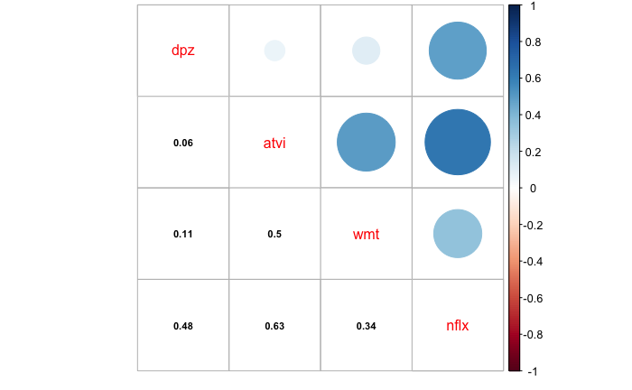

```r
corrplot.mixed(M, lower.col = "black", number.cex = .7)
```

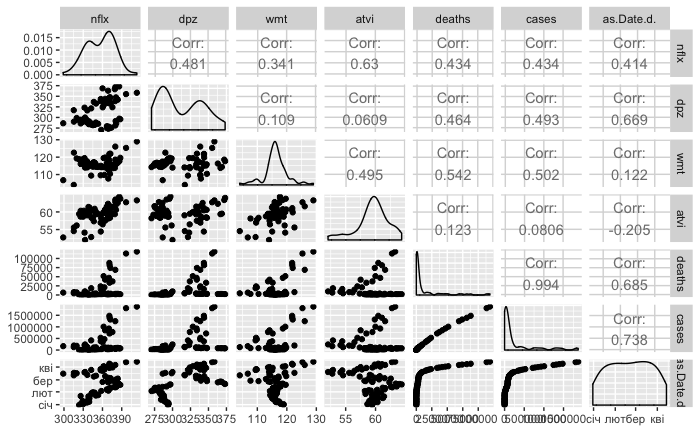

```r
ggpairs(data.frame(nflx,dpz,wmt,atvi,deaths,cases, as.Date(d)))
```

Step 2. Following 2 regressions for evety stock will help us to find a more precise/explaining model and then make a conclusion based on the chosen one

```r
# nflx = B_0+ B_1*deathes + E
n1 <- lm(nflx ~ deaths)
summary(n1)
```

```
Call:
lm(formula = nflx ~ deaths)

Residuals:
    Min      1Q  Median      3Q     Max
-55.057 -12.872  -2.282  16.269  35.558

Coefficients:
             Estimate Std. Error t value Pr(>|t|)
(Intercept) 3.515e+02  2.654e+00 132.480  < 2e-16 ***
deaths      3.616e-04  8.964e-05   4.034 0.000138 ***
---
Signif. codes:  0 ‘***’ 0.001 ‘**’ 0.01 ‘*’ 0.05 ‘.’ 0.1 ‘ ’ 1

Residual standard error: 20.11 on 70 degrees of freedom
Multiple R-squared:  0.1887,    Adjusted R-squared:  0.1771
F-statistic: 16.28 on 1 and 70 DF,  p-value: 0.0001378
```

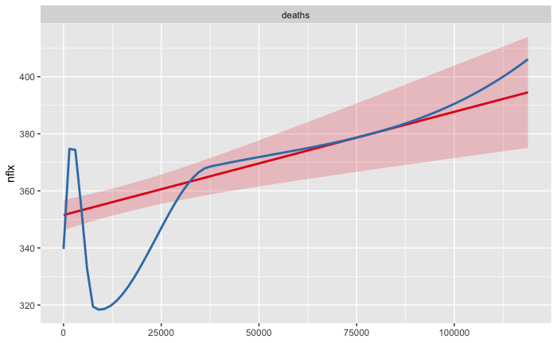

```r
plot_model(n1)
```

```r
#nflx =B_0+ B_1*deaths + B_2*dpz + B_3*atvi + B_4*wmt + E
n2 <- lm(nflx ~ deaths + dpz + atvi + wmt)
summary(n2)
```

```
Call:
lm(formula = nflx ~ deaths + dpz + atvi + wmt)

Residuals:
     Min       1Q   Median       3Q      Max
-25.3367 -10.0944  -0.1996  10.6239  29.1557

Coefficients:
              Estimate Std. Error t value Pr(>|t|)
(Intercept)  6.739e+01  6.363e+01   1.059 0.293378
deaths       2.573e-04  8.497e-05   3.029 0.003487 **
dpz          2.355e-01  6.266e-02   3.758 0.000361 ***
atvi         5.661e+00  7.317e-01   7.736 7.19e-11 ***
wmt         -1.075e+00  5.800e-01  -1.854 0.068174 .
---
Signif. codes:  0 ‘***’ 0.001 ‘**’ 0.01 ‘*’ 0.05 ‘.’ 0.1 ‘ ’ 1

Residual standard error: 13.64 on 67 degrees of freedom
Multiple R-squared:  0.6429,    Adjusted R-squared:  0.6215
F-statistic: 30.15 on 4 and 67 DF,  p-value: 2.36e-14
```

```r
#dpz = 0+ B_1*cases+E
d1 <- lm(dpz ~ cases)
summary(d1)
```

```
Call:
lm(formula = dpz ~ cases)

Residuals:
    Min      1Q  Median      3Q     Max
-33.634 -18.702  -9.951  18.055  66.863

Coefficients:
             Estimate Std. Error t value Pr(>|t|)
(Intercept) 3.038e+02  3.574e+00  85.003  < 2e-16 ***
cases       3.278e-05  6.919e-06   4.738 1.09e-05 ***
---
Signif. codes:  0 ‘***’ 0.001 ‘**’ 0.01 ‘*’ 0.05 ‘.’ 0.1 ‘ ’ 1

Residual standard error: 26.21 on 70 degrees of freedom
Multiple R-squared:  0.2429,    Adjusted R-squared:  0.232
F-statistic: 22.45 on 1 and 70 DF,  p-value: 1.094e-05
```

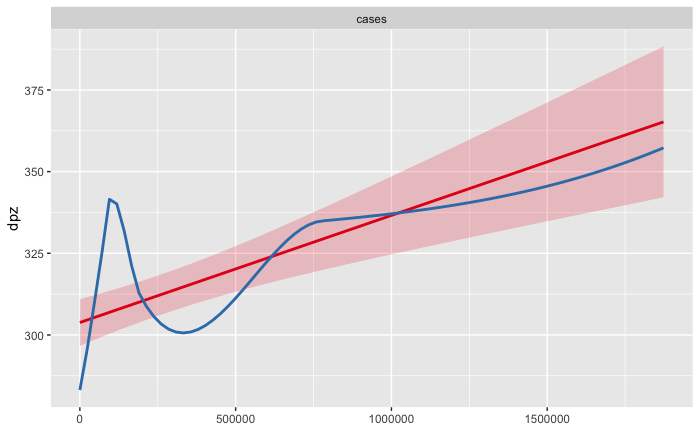

```r
plot_model(d1)
```

```r
#dpz =0+ B_1*cases + B_2*nflx + B_3*atvi + B_4*wmt + E
d2 <- lm(dpz ~ cases + nflx + atvi + wmt)
summary(d2)
```

```
Call:
lm(formula = dpz ~ cases + nflx + atvi + wmt)

Residuals:
    Min      1Q  Median      3Q     Max
-43.970 -14.407  -1.715  11.828  59.703

Coefficients:
              Estimate Std. Error t value Pr(>|t|)
(Intercept)  3.276e+02  1.022e+02   3.205 0.002069 **
cases        2.348e-05  9.046e-06   2.595 0.011605 *
nflx         6.967e-01  1.995e-01   3.492 0.000855 ***
atvi        -2.609e+00  1.776e+00  -1.469 0.146380
wmt         -9.832e-01  1.022e+00  -0.962 0.339659
---
Signif. codes:  0 ‘***’ 0.001 ‘**’ 0.01 ‘*’ 0.05 ‘.’ 0.1 ‘ ’ 1

Residual standard error: 23.97 on 67 degrees of freedom
Multiple R-squared:  0.3939,    Adjusted R-squared:  0.3578
F-statistic: 10.89 on 4 and 67 DF,  p-value: 7.351e-07
```

```r
# wmt = 0+ B_1*deaths+E
w1 <- lm(wmt ~ deaths)
summary(w1)
```

```
Call:
lm(formula = wmt ~ deaths)

Residuals:
     Min       1Q   Median       3Q      Max
-11.5216  -0.9748   0.6681   1.6795   6.7438

Coefficients:
             Estimate Std. Error t value Pr(>|t|)
(Intercept) 1.152e+02  4.437e-01 259.644  < 2e-16 ***
deaths      8.084e-05  1.499e-05   5.394 8.86e-07 ***
---
Signif. codes:  0 ‘***’ 0.001 ‘**’ 0.01 ‘*’ 0.05 ‘.’ 0.1 ‘ ’ 1

Residual standard error: 3.362 on 70 degrees of freedom
Multiple R-squared:  0.2936,    Adjusted R-squared:  0.2835
F-statistic: 29.09 on 1 and 70 DF,  p-value: 8.858e-07
```

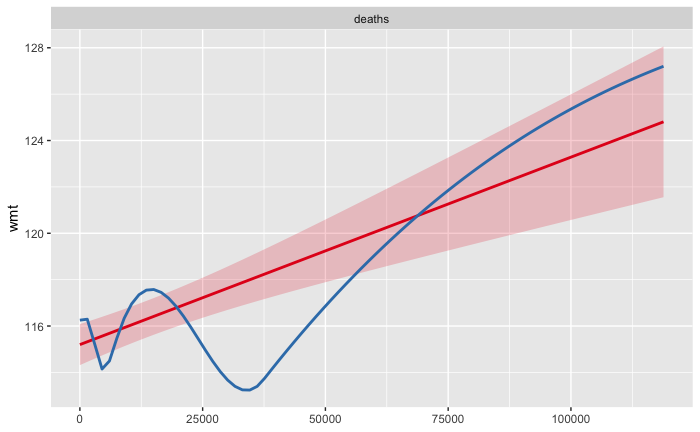

```r
plot_model(w1)
```

```r
#wmt =0+ B_1*deaths + B_2*atvi + B_3*nflx + B_4*dpz + E
w2 <- lm(wmt ~ deaths + atvi + nflx + dpz)
summary(w2)
```

```
Call:
lm(formula = wmt ~ deaths + atvi + nflx + dpz)

Residuals:
    Min      1Q  Median      3Q     Max
-8.8113 -1.0341 -0.2276  1.2052  8.1748

Coefficients:
              Estimate Std. Error t value Pr(>|t|)
(Intercept)  8.232e+01  8.520e+00   9.663 2.53e-14 ***
deaths       9.299e-05  1.474e-05   6.308 2.57e-08 ***
atvi         8.862e-01  1.762e-01   5.029 3.92e-06 ***
nflx        -4.537e-02  2.448e-02  -1.854   0.0682 .
dpz         -1.242e-02  1.408e-02  -0.882   0.3810
---
Signif. codes:  0 ‘***’ 0.001 ‘**’ 0.01 ‘*’ 0.05 ‘.’ 0.1 ‘ ’ 1

Residual standard error: 2.801 on 67 degrees of freedom
Multiple R-squared:  0.5306,    Adjusted R-squared:  0.5026
F-statistic: 18.94 on 4 and 67 DF,  p-value: 1.86e-10
```

```r
#atvi = 0+ B_1*deaths+E
a1 <- lm(atvi ~ deaths)
summary(a1)
```

```
Call:
lm(formula = atvi ~ deaths)

Residuals:
    Min      1Q  Median      3Q     Max
-7.4453 -0.9378  0.0730  1.4204  4.9700

Coefficients:
             Estimate Std. Error t value Pr(>|t|)
(Intercept) 5.938e+01  3.453e-01 171.969   <2e-16 ***
deaths      1.211e-05  1.166e-05   1.038    0.303
---
Signif. codes:  0 ‘***’ 0.001 ‘**’ 0.01 ‘*’ 0.05 ‘.’ 0.1 ‘ ’ 1

Residual standard error: 2.616 on 70 degrees of freedom
Multiple R-squared:  0.01516,   Adjusted R-squared:  0.001092
F-statistic: 1.078 on 1 and 70 DF,  p-value: 0.3028
```

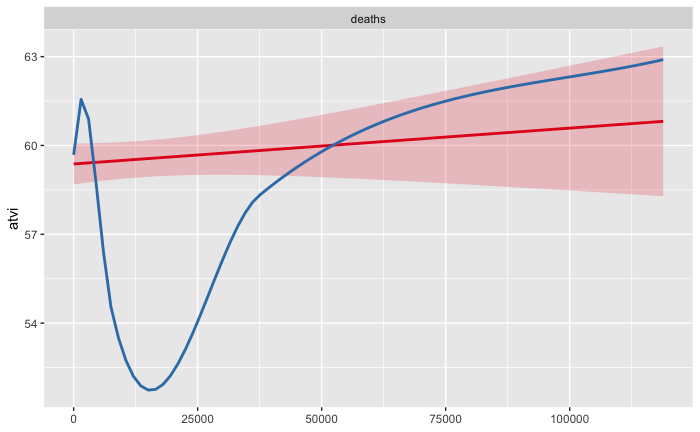

```r
plot_model(a1)
```

```r
#atvi =0+ B_1*deaths + B_2*nflx + B_3*wmt + B_4*dpz +E
a2 <- lm(atvi ~ deaths + nflx + wmt + dpz)
summary(a2)
```

```
Call:
lm(formula = atvi ~ deaths + nflx + wmt + dpz)

Residuals:
    Min      1Q  Median      3Q     Max
-5.1103 -0.7082  0.2410  1.0522  2.7566

Coefficients:
              Estimate Std. Error t value Pr(>|t|)
(Intercept) -1.235e+00  7.785e+00  -0.159 0.874464
deaths      -3.567e-05  1.009e-05  -3.534 0.000747 ***
nflx         8.335e-02  1.077e-02   7.736 7.19e-11 ***
wmt          3.092e-01  6.149e-02   5.029 3.92e-06 ***
dpz         -1.413e-02  8.187e-03  -1.726 0.088918 .
---
Signif. codes:  0 ‘***’ 0.001 ‘**’ 0.01 ‘*’ 0.05 ‘.’ 0.1 ‘ ’ 1

Residual standard error: 1.655 on 67 degrees of freedom
Multiple R-squared:  0.6229,    Adjusted R-squared:  0.6004
F-statistic: 27.67 on 4 and 67 DF,  p-value: 1.411e-13
```

Step 3. -deaths AR(1) forecast deaths_t= B_0+B_1*deaths_lags+ E

```r
# method 1
ar_d <- ar.ols(deaths, order.max = 1, demean = F, intercept = T)
f_d <- forecast(ar_d, newdata=deaths[72])
print(f_d)
```

|  | Point Forecast | Lo 80 | Hi 80 | Lo 95 | Hi 95 |
| --- | --- | --- | --- | --- | --- |
| 73 | 134198.2 | 130778.6 | 137617.8 | 128968.3 | 139428.1 |
| 74 | 151505.0 | 146350.7 | 156659.2 | 143622.2 | 159387.8 |
| 75 | 171022.8 | 164278.7 | 177766.8 | 160708.6 | 181336.9 |
| 76 | 193034.1 | 184695.0 | 201373.2 | 180280.6 | 205787.6 |
| 77 | 217857.5 | 207850.6 | 227864.4 | 202553.3 | 233161.7 |
| 78 | 245852.2 | 234060.2 | 257644.3 | 227817.9 | 263886.6 |
| 79 | 277423.5 | 263692.3 | 291154.7 | 256423.5 | 298423.5 |
| 80 | 313028.2 | 297169.7 | 328886.6 | 288774.7 | 337281.6 |
| 81 | 353181.5 | 334973.0 | 371390.0 | 325334.0 | 381029.0 |
| 82 | 398464.8 | 377647.2 | 419282.3 | 366627.1 | 430302.4 |

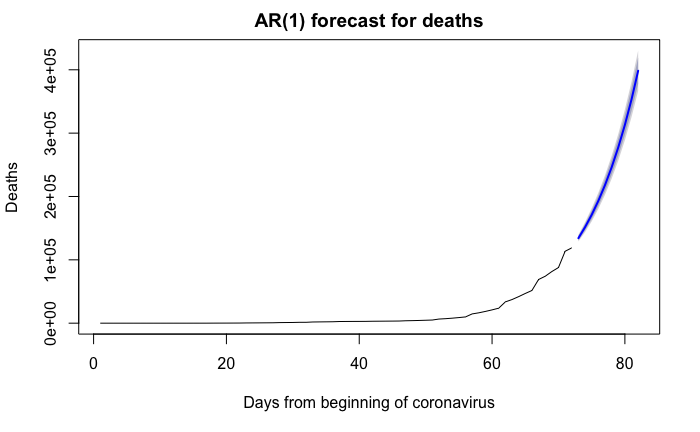

```r
plot(f_d, main="AR(1) forecast for deaths", xlab="Days from beginning of coronavirus", ylab="Deaths")
```

```r
# method 2
deaths_level <- as.numeric(deaths[-1])
deaths_lags <- as.numeric(deaths[-72])
ar_deaths <- dynlm(deaths_level ~ deaths_lags)
summary(ar_deaths)
```

```
Time series regression with "numeric" data:
Start = 1, End = 71

Call:
dynlm(formula = deaths_level ~ deaths_lags)

Residuals:
    Min      1Q  Median      3Q     Max
-9325.1  -399.2  -162.4  -150.2 14315.8

Coefficients:
            Estimate Std. Error t value Pr(>|t|)
(Intercept) 162.1279   359.8351   0.451    0.654
deaths_lags   1.1278     0.0137  82.307   <2e-16 ***
---
Signif. codes:  0 ‘***’ 0.001 ‘**’ 0.01 ‘*’ 0.05 ‘.’ 0.1 ‘ ’ 1

Residual standard error: 2707 on 69 degrees of freedom
Multiple R-squared:  0.9899,    Adjusted R-squared:  0.9898
F-statistic:  6774 on 1 and 69 DF,  p-value: < 2.2e-16
```

-cases AR(1) forecast cases_t= B_0+B_1*cases_lags+ E

```r
# method 1
ar_c <- ar.ols(cases, order.max = 1, demean = F, intercept = T)
f_c <- forecast(ar_c, newdata=cases[72])
print(f_c)
```

|  | Point Forecast | Lo 80 | Hi 80 | Lo 95 | Hi 95 |
| --- | --- | --- | --- | --- | --- |
| 73 | 2064003 | 2015952 | 2112053 | 1990516 | 2137490 |
| 74 | 2273900 | 2202452 | 2345347 | 2164629 | 2383170 |
| 75 | 2504880 | 2412735 | 2597025 | 2363956 | 2645803 |
| 76 | 2759061 | 2646852 | 2871270 | 2587452 | 2930670 |
| 77 | 3038774 | 2906274 | 3171274 | 2836133 | 3241415 |
| 78 | 3346583 | 3193061 | 3500105 | 3111791 | 3581375 |
| 79 | 3685310 | 3509667 | 3860953 | 3416687 | 3953933 |
| 80 | 4058061 | 3858892 | 4257230 | 3753458 | 4362664 |
| 81 | 4468254 | 4243874 | 4692634 | 4125094 | 4811414 |
| 82 | 4919649 | 4668099 | 5171200 | 4534936 | 5304362 |

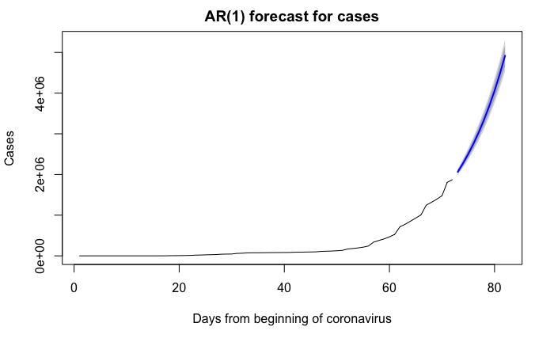

```r
plot(f_c, main="AR(1) forecast for cases", xlab="Days from beginning of coronavirus", ylab="Cases")
```

```r
# method 2
cases_level <- as.numeric(cases[-1])
cases_lags <- as.numeric(cases[-72])
ar_cases <- dynlm(cases_level ~ cases_lags)
summary(ar_cases)
```

```
Time series regression with "numeric" data:
Start = 1, End = 71

Call:
dynlm(formula = cases_level ~ cases_lags)

Residuals:
    Min      1Q  Median      3Q     Max
-118150   -9121   -2581   -1189  179569

Coefficients:
             Estimate Std. Error t value Pr(>|t|)
(Intercept) 2.575e+03  5.226e+03   0.493    0.624
cases_lags  1.100e+00  1.111e-02  99.036   <2e-16 ***
---
Signif. codes:  0 ‘***’ 0.001 ‘**’ 0.01 ‘*’ 0.05 ‘.’ 0.1 ‘ ’ 1

Residual standard error: 38030 on 69 degrees of freedom
Multiple R-squared:  0.993, Adjusted R-squared:  0.9929
F-statistic:  9808 on 1 and 69 DF,  p-value: < 2.2e-16
```

-nflx forecast using 3 models

Model 1 nflx_level=B_0+B_1*nflx_lags+E

```r
# method 1
ar_nf <- ar.ols(nflx, order.max = 1, demean = F, intercept = T)
f_nf <- forecast(ar_nf, newdata=nflx[72])
print(f_nf)
```

|  | Point Forecast | Lo 80 | Hi 80 | Lo 95 | Hi 95 |
| --- | --- | --- | --- | --- | --- |
| 73 | 406.7656 | 391.2677 | 422.2635 | 383.0636 | 430.4676 |
| 74 | 400.9231 | 380.4705 | 421.3756 | 369.6436 | 432.2025 |
| 75 | 395.8918 | 372.4311 | 419.3524 | 360.0118 | 431.7717 |
| 76 | 391.5590 | 366.0960 | 417.0219 | 352.6167 | 430.5012 |
| 77 | 387.8277 | 360.9761 | 414.6794 | 346.7617 | 428.8938 |
| 78 | 384.6145 | 356.7777 | 412.4513 | 342.0418 | 427.1872 |
| 79 | 381.8474 | 353.3020 | 410.3929 | 338.1910 | 425.5039 |
| 80 | 379.4645 | 350.4047 | 408.5243 | 335.0214 | 423.9077 |
| 81 | 377.4125 | 347.9770 | 406.8479 | 332.3948 | 422.4301 |
| 82 | 375.6453 | 345.9343 | 405.3563 | 330.2063 | 421.0843 |

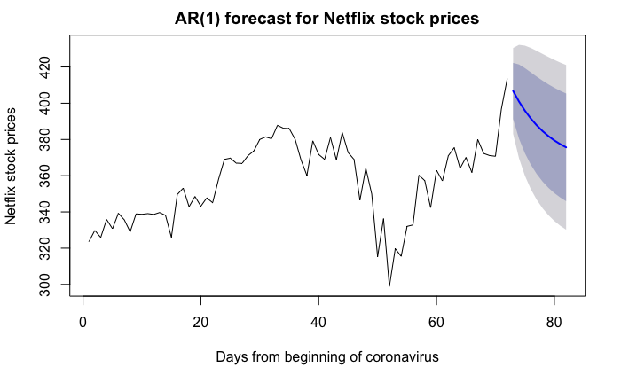

```r
plot(f_nf, main="AR(1) forecast for Netflix stock prices", xlab="Days from beginning of coronavirus", ylab="Netflix stock prices")
```

```r
# method 2
nflx_level <- as.numeric(nflx[-1])
nflx_lags <- as.numeric(nflx[-72])
ar_nflx <- dynlm(nflx_level ~ nflx_lags)
summary(ar_nflx)
```

```
Time series regression with "numeric" data:
Start = 1, End = 71

Call:
dynlm(formula = nflx_level ~ nflx_lags)

Residuals:
    Min      1Q  Median      3Q     Max
-41.401  -7.350   0.135   6.743  26.838

Coefficients:
            Estimate Std. Error t value Pr(>|t|)
(Intercept) 50.63190   24.59183   2.059   0.0433 *
nflx_lags    0.86116    0.06904  12.473   <2e-16 ***
---
Signif. codes:  0 ‘***’ 0.001 ‘**’ 0.01 ‘*’ 0.05 ‘.’ 0.1 ‘ ’ 1

Residual standard error: 12.27 on 69 degrees of freedom
Multiple R-squared:  0.6927,    Adjusted R-squared:  0.6883
F-statistic: 155.6 on 1 and 69 DF,  p-value: < 2.2e-16
```

Model 2 nflx_level=B_0+1nflx_lags+ B_2deaths_lags+ E

```r
ar_nflx1 <- dynlm(nflx_level ~ nflx_lags+deaths_lags)
future_n_d<-forecast(ar_nflx1, newdata=data.frame(nflx_lags=nflx[72], deaths_lags=c(deaths[72],f_d$mean)))
plot(x = c(1:82),y=c(future_n_d$x,future_n_d$mean),type = 'l', ylim=c(295, 480), main="AR(1)+deaths forecast for Netflix stock prices", xlab="Days from beginning of coronavirus", ylab="Netflix stock prices", col="blue")
lines(x=c(72:82),y=future_n_d$upper[,1], col = "orange", lty=2)
```

```r
lines(x=c(72:82),y=future_n_d$lower[,1], col = "orange", lty=2)
lines(x=c(72:82),y=future_n_d$upper[,2], col = "red", lty=2)
```

```r
lines(x=c(72:82),y=future_n_d$lower[,2], col = "red", lty=2)
abline(v=72, col='red')
```

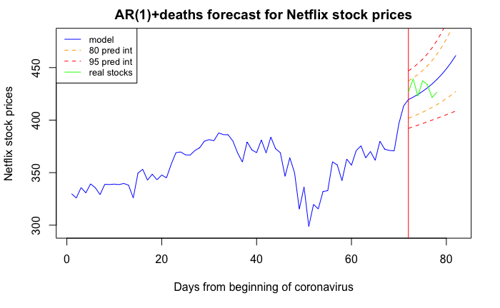

```r
lines(x=c(72:78),y=nflx_new, col = "green")
legend("topleft", legend=c("model", "80 pred int", "95 pred int", "real stocks"),
       col=c("blue", "orange","red", "green"), lty = c(1,2,2,1), cex=0.8)
```

```r
summary(ar_nflx1)
```

```
Time series regression with "numeric" data:
Start = 1, End = 71

Call:
dynlm(formula = nflx_level ~ nflx_lags + deaths_lags)

Residuals:
    Min      1Q  Median      3Q     Max
-41.476  -6.717   0.492   7.466  22.003

Coefficients:
             Estimate Std. Error t value Pr(>|t|)
(Intercept) 6.932e+01  2.512e+01   2.760  0.00742 **
nflx_lags   8.036e-01  7.124e-02  11.280  < 2e-16 ***
deaths_lags 1.505e-04  6.407e-05   2.349  0.02174 *
---
Signif. codes:  0 ‘***’ 0.001 ‘**’ 0.01 ‘*’ 0.05 ‘.’ 0.1 ‘ ’ 1

Residual standard error: 11.88 on 68 degrees of freedom
Multiple R-squared:  0.7158,    Adjusted R-squared:  0.7074
F-statistic: 85.64 on 2 and 68 DF,  p-value: < 2.2e-16
```

```r
print(future_n_d)
```

|  | Point Forecast | Lo 80 | Hi 80 | Lo 95 | Hi 95 |
| --- | --- | --- | --- | --- | --- |
| 1 | 419.5320 | 401.7967 | 437.2674 | 392.1851 | 446.8790 |
| 2 | 421.8415 | 403.5642 | 440.1189 | 393.6588 | 450.0242 |
| 3 | 424.4461 | 405.4735 | 443.4187 | 395.1913 | 453.7008 |
| 4 | 427.3834 | 407.5312 | 447.2356 | 396.7724 | 457.9944 |
| 5 | 430.6960 | 409.7459 | 451.6461 | 398.3921 | 462.9998 |
| 6 | 434.4318 | 412.1289 | 456.7346 | 400.0420 | 468.8215 |
| 7 | 438.6448 | 414.6955 | 462.5941 | 401.7163 | 475.5733 |
| 8 | 443.3961 | 417.4657 | 469.3264 | 403.4130 | 483.3792 |
| 9 | 448.7544 | 420.4655 | 477.0432 | 405.1345 | 492.3742 |
| 10 | 454.7972 | 423.7265 | 485.8679 | 406.8879 | 502.7065 |

[output cut: 1 more lines]

Model 3 nflx_level =B_0+1 nflx_lags + B_2deaths_lags + B_3atvi_lags + B_4wmt_lags + B_5dpz_lags+E

```r
ar_nflx2 <- dynlm(nflx_level ~ nflx_lags+deaths_lags+atvi_lags+wmt_lags+dpz_lags)
future_n_d_2<-forecast(ar_nflx2, newdata=data.frame(nflx_lags=nflx[72], deaths_lags=c(deaths[72],f_d$mean), atvi_lags=c(atvi[72],future_a_d$mean[1:10]), wmt_lags=c(wmt[72],future_w_d$mean[1:10]), dpz_lags=c(dpz[72],future_d_d$mean[1:10])))
plot(x = c(1:82),y=c(future_n_d_2$x,future_n_d_2$mean),type = 'l', main="+other stock prices for Netflix stock prices", xlab="Days from beginning of coronavirus", ylab="Netflix stock prices", col="purple")
lines(x=c(72:82),y=future_n_d_2$upper[,1], col = "orange", lty=2)
```

```r
lines(x=c(72:82),y=future_n_d_2$lower[,1], col = "orange", lty=2)
lines(x=c(72:82),y=future_n_d_2$upper[,2], col = "red", lty=2)
```

```r
lines(x=c(72:82),y=future_n_d_2$lower[,2], col = "red", lty=2)
abline(v=72, col='red')
```

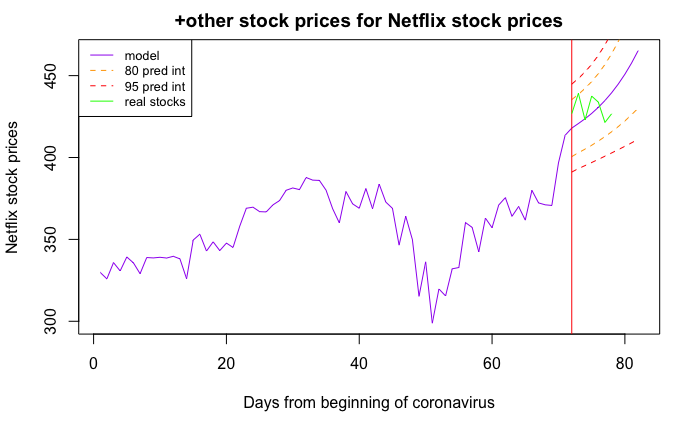

```r
lines(x=c(72:78),y=nflx_new, col = "green")
legend("topleft", legend=c("model", "80 pred int", "95 pred int", "real stocks"),
       col=c("purple", "orange","red", "green"), lty = c(1,2,2,1), cex=0.8)
```

```r
summary(ar_nflx2)
```

```
Time series regression with "numeric" data:
Start = 1, End = 71

Call:
dynlm(formula = nflx_level ~ nflx_lags + deaths_lags + atvi_lags +
    wmt_lags + dpz_lags)

Residuals:
    Min      1Q  Median      3Q     Max
-39.302  -5.414   1.593   6.758  25.657

Coefficients:
              Estimate Std. Error t value Pr(>|t|)
(Intercept)  1.845e+02  5.480e+01   3.367  0.00128 **
nflx_lags    9.518e-01  1.037e-01   9.183 2.37e-13 ***
deaths_lags  2.186e-04  7.901e-05   2.767  0.00736 **
atvi_lags   -9.512e-01  8.488e-01  -1.121  0.26654
wmt_lags    -6.528e-01  5.058e-01  -1.291  0.20138
dpz_lags    -1.167e-01  5.821e-02  -2.004  0.04921 *
---
Signif. codes:  0 ‘***’ 0.001 ‘**’ 0.01 ‘*’ 0.05 ‘.’ 0.1 ‘ ’ 1

Residual standard error: 11.48 on 65 degrees of freedom
Multiple R-squared:  0.7464,    Adjusted R-squared:  0.7268
F-statistic: 38.25 on 5 and 65 DF,  p-value: < 2.2e-16
```

```r
print(future_n_d_2)
```

|  | Point Forecast | Lo 80 | Hi 80 | Lo 95 | Hi 95 |
| --- | --- | --- | --- | --- | --- |
| 1 | 417.9539 | 400.5461 | 435.3616 | 391.1018 | 444.8059 |
| 2 | 420.7456 | 402.9153 | 438.5759 | 393.2417 | 448.2495 |
| 3 | 423.6464 | 405.1171 | 442.1756 | 395.0644 | 452.2284 |
| 4 | 426.9218 | 407.4852 | 446.3584 | 396.9402 | 456.9035 |
| 5 | 430.6202 | 410.0289 | 451.2115 | 398.8574 | 462.3830 |
| 6 | 434.7960 | 412.7619 | 456.8302 | 400.8076 | 468.7845 |
| 7 | 439.5108 | 415.7032 | 463.3183 | 402.7868 | 476.2348 |
| 8 | 444.8338 | 418.8786 | 470.7890 | 404.7970 | 484.8706 |
| 9 | 450.8435 | 422.3211 | 479.3660 | 406.8467 | 494.8404 |
| 10 | 457.6283 | 426.0711 | 489.1854 | 408.9503 | 506.3062 |

[output cut: 1 more lines]

-dpz forecast using 3 models

Model 1 dmz_level=dmz_lags+E

```r
# method 1
ar_dpz1 <- ar.ols(dpz, order.max = 1, demean = F, intercept = T)
f_dpz <- forecast(ar_dpz1, newdata=dpz[72])
print(f_dpz)
```

|  | Point Forecast | Lo 80 | Hi 80 | Lo 95 | Hi 95 |
| --- | --- | --- | --- | --- | --- |
| 73 | 354.9676 | 338.0551 | 371.8801 | 329.1022 | 380.8330 |
| 74 | 351.9721 | 329.1074 | 374.8369 | 317.0035 | 386.9408 |
| 75 | 349.2468 | 322.4367 | 376.0569 | 308.2443 | 390.2494 |
| 76 | 346.7673 | 317.0854 | 376.4491 | 301.3728 | 392.1617 |
| 77 | 344.5114 | 312.6476 | 376.3751 | 295.7800 | 393.2428 |
| 78 | 342.4589 | 308.8962 | 376.0216 | 291.1292 | 393.7887 |
| 79 | 340.5915 | 305.6850 | 375.4981 | 287.2066 | 393.9765 |
| 80 | 338.8926 | 302.9116 | 374.8736 | 283.8644 | 393.9208 |
| 81 | 337.3469 | 300.5002 | 374.1935 | 280.9948 | 393.6990 |
| 82 | 335.9406 | 298.3924 | 373.4887 | 278.5156 | 393.3655 |

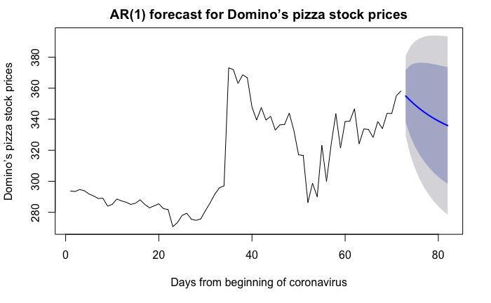

```r
plot(f_dpz, main="AR(1) forecast for Domino’s pizza stock prices", xlab="Days from beginning of coronavirus", ylab="Domino’s pizza stock prices")
```

```r
# method 2
dpz_level <- as.numeric(dpz[-1])
dpz_lags <- as.numeric(dpz[-72])
ar_dpz <- dynlm(dpz_level ~ dpz_lags)
summary(ar_dpz)
```

```
Time series regression with "numeric" data:
Start = 1, End = 71

Call:
dynlm(formula = dpz_level ~ dpz_lags)

Residuals:
    Min      1Q  Median      3Q     Max
-30.772  -4.719  -2.215   2.892  73.837

Coefficients:
            Estimate Std. Error t value Pr(>|t|)
(Intercept) 29.01783   16.91383   1.716   0.0907 .
dpz_lags     0.90981    0.05403  16.840   <2e-16 ***
---
Signif. codes:  0 ‘***’ 0.001 ‘**’ 0.01 ‘*’ 0.05 ‘.’ 0.1 ‘ ’ 1

Residual standard error: 13.39 on 69 degrees of freedom
Multiple R-squared:  0.8043,    Adjusted R-squared:  0.8015
F-statistic: 283.6 on 1 and 69 DF,  p-value: < 2.2e-16
```

Model 2 dmz_level=B_0+B_1dmz_lags+B_cases_lags+E

```r
ar_dpz1 <- dynlm(dpz_level ~ dpz_lags+cases_lags)
future_d_d<-forecast(ar_dpz1, newdata=data.frame(dpz_lags=dpz[72], cases_lags=c(cases[72],f_c$mean)))
plot(x = c(1:82),y=c(future_d_d$x,future_d_d$mean),type = 'l', ylim = c(270,420), main="AR(1)+deaths forecast for Domino’s pizza stock prices", xlab="Days from beginning of coronavirus", ylab="Domino’s pizza stock prices", col="blue")
lines(x=c(72:82),y=future_d_d$upper[,1], col = "orange", lty=2)
```

```r
lines(x=c(72:82),y=future_d_d$lower[,1], col = "orange", lty=2)
lines(x=c(72:82),y=future_d_d$upper[,2], col = "red", lty=2)
```

```r
lines(x=c(72:82),y=future_d_d$lower[,2], col = "red", lty=2)
abline(v=72, col='red')
```

[figure not shown]

```r
lines(x=c(72:78),y=dpz_new, col = "green")
legend("topleft", legend=c("model", "80 pred int", "95 pred int", "real stocks"),
       col=c("blue", "orange","red", "green"), lty = c(1,2,2,1), cex=0.8)
```

```r
summary(ar_dpz1)
```

```
Time series regression with "numeric" data:
Start = 1, End = 71

Call:
dynlm(formula = dpz_level ~ dpz_lags + cases_lags)

Residuals:
    Min      1Q  Median      3Q     Max
-29.866  -4.666  -2.086   4.134  74.292

Coefficients:
             Estimate Std. Error t value Pr(>|t|)
(Intercept) 4.091e+01  1.846e+01   2.216     0.03 *
dpz_lags    8.666e-01  6.048e-02  14.327   <2e-16 ***
cases_lags  6.713e-06  4.378e-06   1.533     0.13
---
Signif. codes:  0 ‘***’ 0.001 ‘**’ 0.01 ‘*’ 0.05 ‘.’ 0.1 ‘ ’ 1

Residual standard error: 13.26 on 68 degrees of freedom
Multiple R-squared:  0.8108,    Adjusted R-squared:  0.8053
F-statistic: 145.7 on 2 and 68 DF,  p-value: < 2.2e-16
```

```r
print(future_d_d)
```

|  | Point Forecast | Lo 80 | Hi 80 | Lo 95 | Hi 95 |
| --- | --- | --- | --- | --- | --- |
| 1 | 363.9377 | 344.8004 | 383.0749 | 334.4290 | 393.4463 |
| 2 | 365.2181 | 345.6281 | 384.8081 | 335.0114 | 395.4248 |
| 3 | 366.6272 | 346.4836 | 386.7708 | 335.5669 | 397.6875 |
| 4 | 368.1778 | 347.3634 | 388.9921 | 336.0831 | 400.2724 |
| 5 | 369.8841 | 348.2639 | 391.5043 | 336.5470 | 403.2212 |
| 6 | 371.7618 | 349.1819 | 394.3418 | 336.9448 | 406.5789 |
| 7 | 373.8282 | 350.1144 | 397.5420 | 337.2629 | 410.3935 |
| 8 | 376.1021 | 351.0594 | 401.1448 | 337.4876 | 414.7166 |
| 9 | 378.6044 | 352.0158 | 405.1931 | 337.6063 | 419.6026 |
| 10 | 381.3581 | 352.9838 | 409.7324 | 337.6065 | 425.1097 |

[output cut: 1 more lines]

Model 3 dmz_level=B_0+B_1dmz_lags+B_2cases_lags+B_3atvi_lags+B_4wmt_lags+B_5nflx_lags+E

```r
ar_dpz2 <- dynlm(dpz_level ~ dpz_lags+cases_lags+atvi_lags+wmt_lags+nflx_lags)
future_d_d_2<-forecast(ar_dpz2, newdata=data.frame(dpz_lags=dpz[72], cases_lags=c(cases[72],f_c$mean), atvi_lags=c(atvi[72],future_a_d$mean[1:10]), wmt_lags=c(wmt[72],future_w_d$mean[1:10]), nflx_lags=c(nflx[72],future_n_d$mean[1:10])))
plot(x = c(1:82),y=c(future_d_d_2$x,future_d_d_2$mean),type = 'l', ylim = c(270,420), main="+other stock prices for Domino’s pizza stock prices", xlab="Days from beginning of coronavirus", ylab="Domino’s pizza stock prices", col="purple")
lines(x=c(72:82),y=future_d_d_2$upper[,1], col = "orange", lty=2)
```

```r
lines(x=c(72:82),y=future_d_d_2$lower[,1], col = "orange", lty=2)
lines(x=c(72:82),y=future_d_d_2$upper[,2], col = "red", lty=2)
```

```r
lines(x=c(72:82),y=future_d_d_2$lower[,2], col = "red", lty=2)
abline(v=72, col='red')
```

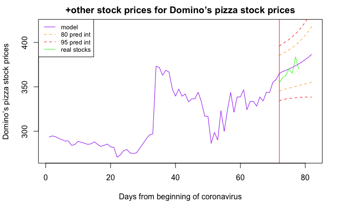

```r
lines(x=c(72:78),y=dpz_new, col = "green")
legend("topleft", legend=c("model", "80 pred int", "95 pred int", "real stocks"),
       col=c("purple", "orange","red", "green"), lty = c(1,2,2,1), cex=0.8)
```

```r
summary(ar_dpz2)
```

```
Time series regression with "numeric" data:
Start = 1, End = 71

Call:
dynlm(formula = dpz_level ~ dpz_lags + cases_lags + atvi_lags +
    wmt_lags + nflx_lags)

Residuals:
    Min      1Q  Median      3Q     Max
-28.005  -5.460  -1.704   3.753  71.421

Coefficients:
              Estimate Std. Error t value Pr(>|t|)
(Intercept)  5.243e+01  6.281e+01   0.835    0.407
dpz_lags     8.292e-01  6.837e-02  12.128   <2e-16 ***
cases_lags   6.817e-06  5.408e-06   1.260    0.212
atvi_lags   -1.767e-01  1.010e+00  -0.175    0.862
wmt_lags    -2.723e-01  5.850e-01  -0.465    0.643
nflx_lags    1.188e-01  1.223e-01   0.971    0.335
---
Signif. codes:  0 ‘***’ 0.001 ‘**’ 0.01 ‘*’ 0.05 ‘.’ 0.1 ‘ ’ 1

Residual standard error: 13.4 on 65 degrees of freedom
Multiple R-squared:  0.8154,    Adjusted R-squared:  0.8012
F-statistic: 57.43 on 5 and 65 DF,  p-value: < 2.2e-16
```

```r
print(future_d_d_2)
```

|  | Point Forecast | Lo 80 | Hi 80 | Lo 95 | Hi 95 |
| --- | --- | --- | --- | --- | --- |
| 1 | 365.0698 | 345.0711 | 385.0685 | 334.2211 | 395.9185 |
| 2 | 367.1388 | 346.7445 | 387.5330 | 335.6799 | 398.5976 |
| 3 | 368.5710 | 347.6376 | 389.5045 | 336.2805 | 400.8616 |
| 4 | 370.1472 | 348.5532 | 391.7412 | 336.8378 | 403.4567 |
| 5 | 371.8818 | 349.4873 | 394.2762 | 337.3375 | 406.4260 |
| 6 | 373.7906 | 350.4359 | 397.1452 | 337.7653 | 409.8159 |
| 7 | 375.8912 | 351.3959 | 400.3865 | 338.1063 | 413.6760 |
| 8 | 378.2028 | 352.3646 | 404.0411 | 338.3465 | 418.0592 |
| 9 | 380.7468 | 353.3407 | 408.1528 | 338.4720 | 423.0216 |
| 10 | 383.5463 | 354.3239 | 412.7688 | 338.4697 | 428.6229 |

[output cut: 1 more lines]

-atvi forecast using 3 models

Model 1 atvi_level=B_0+1atvi_lags+E

```r
# method 1
ar_a <- ar.ols(atvi, order.max = 1, demean = F, intercept = T)
f_a <- forecast(ar_a, newdata=atvi[72])
print(f_a)
```

|  | Point Forecast | Lo 80 | Hi 80 | Lo 95 | Hi 95 |
| --- | --- | --- | --- | --- | --- |
| 73 | 62.32168 | 60.00205 | 64.64132 | 58.77411 | 65.86926 |
| 74 | 61.61904 | 58.74270 | 64.49538 | 57.22005 | 66.01802 |
| 75 | 61.10385 | 57.96882 | 64.23888 | 56.30924 | 65.89846 |
| 76 | 60.72611 | 57.46048 | 63.99175 | 55.73175 | 65.72047 |
| 77 | 60.44915 | 57.11542 | 63.78289 | 55.35064 | 65.54766 |
| 78 | 60.24608 | 56.87630 | 63.61586 | 55.09245 | 65.39972 |
| 79 | 60.09719 | 56.70820 | 63.48619 | 54.91417 | 65.28021 |
| 80 | 59.98802 | 56.58874 | 63.38731 | 54.78927 | 65.18678 |
| 81 | 59.90798 | 56.50318 | 63.31278 | 54.70079 | 65.11517 |
| 82 | 59.84929 | 56.44153 | 63.25705 | 54.63757 | 65.06101 |

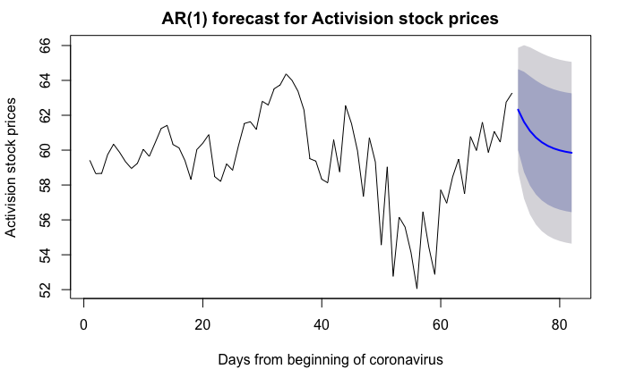

```r
plot(f_a, main="AR(1) forecast for Activision stock prices", xlab="Days from beginning of coronavirus", ylab="Activision stock prices")
```

```r
# method 2
atvi_level <- as.numeric(atvi[-1])
atvi_lags <- as.numeric(atvi[-72])
ar_atvi <- dynlm(atvi_level ~ atvi_lags)
summary(ar_atvi)
```

```
Time series regression with "numeric" data:
Start = 1, End = 71

Call:
dynlm(formula = atvi_level ~ atvi_lags)

Residuals:
    Min      1Q  Median      3Q     Max
-6.4529 -0.9514  0.0781  1.2144  3.5497

Coefficients:
            Estimate Std. Error t value Pr(>|t|)
(Intercept) 15.92431    5.03001   3.166   0.0023 **
atvi_lags    0.73321    0.08448   8.679 1.15e-12 ***
---
Signif. codes:  0 ‘***’ 0.001 ‘**’ 0.01 ‘*’ 0.05 ‘.’ 0.1 ‘ ’ 1

Residual standard error: 1.836 on 69 degrees of freedom
Multiple R-squared:  0.5219,    Adjusted R-squared:  0.515
F-statistic: 75.32 on 1 and 69 DF,  p-value: 1.148e-12
```

Model 2 atvi_level=B_0+ B_1atvi_lags+B_2deaths_lags+E

```r
ar_atvi1 <- dynlm(atvi_level ~ atvi_lags+deaths_lags)
future_a_d<-forecast(ar_atvi1, newdata=data.frame(atvi_lags=atvi[72], deaths_lags=c(deaths[72],f_d$mean)))
plot(x = c(1:82),y=c(future_a_d$x,future_a_d$mean),type = 'l', ylim=c(51,73), main="AR(1)+deaths forecast for Activision stock prices", xlab="Days from beginning of coronavirus", ylab="Activision stock prices", col="blue")
lines(x=c(72:82),y=future_a_d$upper[,1], col = "orange", lty=2)
```

```r
lines(x=c(72:82),y=future_a_d$lower[,1], col = "orange", lty=2)
lines(x=c(72:82),y=future_a_d$upper[,2], col = "red", lty=2)
```

```r
lines(x=c(72:82),y=future_a_d$lower[,2], col = "red", lty=2)
abline(v=72, col='red')
```

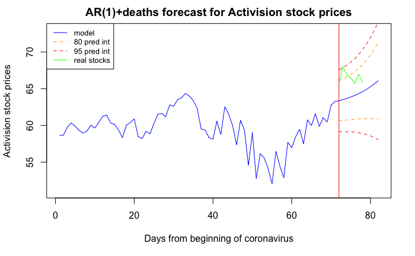

```r
lines(x=c(72:78),y=atvi_new, col = "green")
legend("topleft", legend=c("model", "80 pred int", "95 pred int", "real stocks"),
       col=c("blue", "orange","red", "green"), lty = c(1,2,2,1), cex=0.8)
```

```r
summary(ar_atvi1)
```

```
Time series regression with "numeric" data:
Start = 1, End = 71

Call:
dynlm(formula = atvi_level ~ atvi_lags + deaths_lags)

Residuals:
    Min      1Q  Median      3Q     Max
-6.3873 -0.9438  0.1949  1.0627  3.6323

Coefficients:
             Estimate Std. Error t value Pr(>|t|)
(Intercept) 1.607e+01  5.027e+00   3.196  0.00212 **
atvi_lags   7.289e-01  8.451e-02   8.625 1.61e-12 ***
deaths_lags 9.836e-06  9.297e-06   1.058  0.29383
---
Signif. codes:  0 ‘***’ 0.001 ‘**’ 0.01 ‘*’ 0.05 ‘.’ 0.1 ‘ ’ 1

Residual standard error: 1.834 on 68 degrees of freedom
Multiple R-squared:  0.5297,    Adjusted R-squared:  0.5158
F-statistic: 38.29 on 2 and 68 DF,  p-value: 7.282e-12
```

```r
print(future_a_d)
```

|  | Point Forecast | Lo 80 | Hi 80 | Lo 95 | Hi 95 |
| --- | --- | --- | --- | --- | --- |
| 1 | 63.35781 | 60.62032 | 66.09529 | 59.13676 | 67.57886 |
| 2 | 63.50875 | 60.68104 | 66.33647 | 59.14858 | 67.86893 |
| 3 | 63.67898 | 60.73890 | 66.61906 | 59.14554 | 68.21242 |
| 4 | 63.87096 | 60.79216 | 66.94976 | 59.12362 | 68.61829 |
| 5 | 64.08746 | 60.83893 | 67.33599 | 59.07840 | 69.09651 |
| 6 | 64.33162 | 60.87729 | 67.78595 | 59.00523 | 69.65801 |
| 7 | 64.60697 | 60.90533 | 68.30861 | 58.89925 | 70.31470 |
| 8 | 64.91750 | 60.92123 | 68.91378 | 58.75547 | 71.07954 |
| 9 | 65.26771 | 60.92325 | 69.61217 | 58.56880 | 71.96662 |
| 10 | 65.66265 | 60.90979 | 70.41552 | 58.33400 | 72.99131 |

[output cut: 1 more lines]

Model 3 atvi_level=B_0+B_1atvi_lags+B_2deaths_lags+B_3nflx_lags+B_4wmt_lags+B_5dpz_lags+E

```r
ar_atvi2 <- dynlm(atvi_level ~ atvi_lags+deaths_lags+nflx_lags+wmt_lags+dpz_lags)
future_a_d_2<-forecast(ar_atvi2, newdata=data.frame(atvi_lags=atvi[72], deaths_lags=c(deaths[72],f_d$mean), nflx_lags=c(nflx[72],future_n_d$mean[1:10]), wmt_lags=c(wmt[72],future_w_d$mean[1:10]), dpz_lags=c(dpz[72],future_d_d$mean[1:10])))
plot(x = c(1:82),y=c(future_a_d_2$x,future_a_d_2$mean),type = 'l', main="+other stock prices for Activision stock prices", xlab="Days from beginning of coronavirus", ylab="Actiovision stock prices", col="purple")
lines(x=c(72:82),y=future_a_d_2$upper[,1], col = "orange", lty=2)
```

```r
lines(x=c(72:82),y=future_a_d_2$lower[,1], col = "orange", lty=2)
lines(x=c(72:82),y=future_a_d_2$upper[,2], col = "red", lty=2)
```

```r
lines(x=c(72:82),y=future_a_d_2$lower[,2], col = "red", lty=2)
abline(v=72, col='red')
```

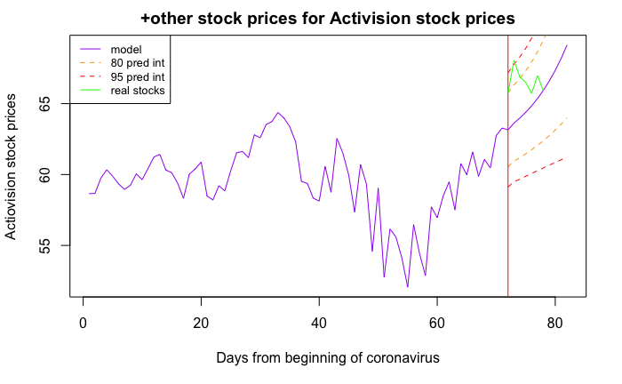

```r
lines(x=c(72:78),y=atvi_new, col = "green")
legend("topleft", legend=c("model", "80 pred int", "95 pred int", "real stocks"),
       col=c("purple", "orange","red", "green"), lty = c(1,2,2,1), cex=0.8)
```

```r
summary(ar_atvi2)
```

```
Time series regression with "numeric" data:
Start = 1, End = 71

Call:
dynlm(formula = atvi_level ~ atvi_lags + deaths_lags + nflx_lags +
    wmt_lags + dpz_lags)

Residuals:
    Min      1Q  Median      3Q     Max
-6.1726 -0.8524  0.2154  1.0035  3.9725

Coefficients:
              Estimate Std. Error t value Pr(>|t|)
(Intercept)  3.625e+01  8.218e+00   4.412 3.95e-05 ***
atvi_lags    7.700e-01  1.273e-01   6.050 7.94e-08 ***
deaths_lags  2.988e-05  1.185e-05   2.522   0.0141 *
nflx_lags    1.649e-02  1.554e-02   1.061   0.2926
wmt_lags    -1.862e-01  7.584e-02  -2.456   0.0167 *
dpz_lags    -2.282e-02  8.728e-03  -2.615   0.0111 *
---
Signif. codes:  0 ‘***’ 0.001 ‘**’ 0.01 ‘*’ 0.05 ‘.’ 0.1 ‘ ’ 1

Residual standard error: 1.722 on 65 degrees of freedom
Multiple R-squared:  0.6039,    Adjusted R-squared:  0.5734
F-statistic: 19.82 on 5 and 65 DF,  p-value: 6.063e-12
```

```r
print(future_a_d_2)
```

|  | Point Forecast | Lo 80 | Hi 80 | Lo 95 | Hi 95 |
| --- | --- | --- | --- | --- | --- |
| 1 | 63.14951 | 60.53924 | 65.75978 | 59.12308 | 67.17594 |
| 2 | 63.62648 | 60.94051 | 66.31245 | 59.48328 | 67.76968 |
| 3 | 63.98414 | 61.19266 | 66.77562 | 59.67819 | 68.29010 |
| 4 | 64.38830 | 61.46306 | 67.31354 | 59.87602 | 68.90058 |
| 5 | 64.84496 | 61.75253 | 67.93740 | 60.07478 | 69.61515 |
| 6 | 65.36094 | 62.06233 | 68.65955 | 60.27272 | 70.44916 |
| 7 | 65.94390 | 62.39425 | 69.49354 | 60.46845 | 71.41935 |
| 8 | 66.60250 | 62.75081 | 70.45420 | 60.66113 | 72.54387 |
| 9 | 67.34653 | 63.13529 | 71.55778 | 60.85055 | 73.84252 |
| 10 | 68.18704 | 63.55184 | 72.82224 | 61.03709 | 75.33699 |

[output cut: 1 more lines]

-wmt forecast using 3 models

Model 1 wmt_level=B_0+B_1wmt_lags+E

```r
# method 1
ar_w <- ar.ols(wmt, order.max = 1, demean = F, intercept = T)
f_w <- forecast(ar_w, newdata=wmt[72])
print(f_w)
```

|  | Point Forecast | Lo 80 | Hi 80 | Lo 95 | Hi 95 |
| --- | --- | --- | --- | --- | --- |
| 73 | 124.5826 | 120.5192 | 128.6461 | 118.3681 | 130.7971 |
| 74 | 121.7264 | 116.8876 | 126.5653 | 114.3260 | 129.1268 |
| 75 | 119.8796 | 114.7512 | 125.0080 | 112.0364 | 127.7228 |
| 76 | 118.6855 | 113.4408 | 123.9302 | 110.6644 | 126.7066 |
| 77 | 117.9134 | 112.6208 | 123.2060 | 109.8191 | 126.0077 |
| 78 | 117.4142 | 112.1017 | 122.7266 | 109.2895 | 125.5389 |
| 79 | 117.0914 | 111.7706 | 122.4121 | 108.9540 | 125.2288 |
| 80 | 116.8827 | 111.5584 | 122.2069 | 108.7400 | 125.0254 |
| 81 | 116.7477 | 111.4220 | 122.0734 | 108.6028 | 124.8926 |
| 82 | 116.6605 | 111.3342 | 121.9867 | 108.5146 | 124.8063 |

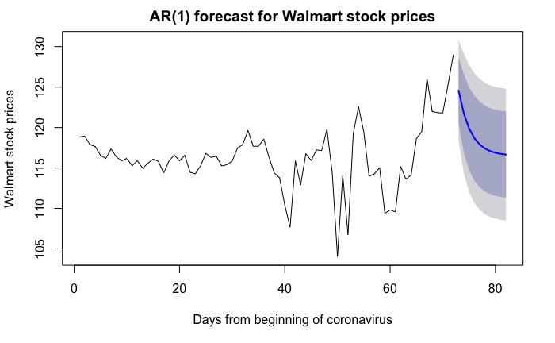

```r
plot(f_w, main="AR(1) forecast for Walmart stock prices", xlab="Days from beginning of coronavirus", ylab="Walmart stock prices")
```

```r
# method 2
wmt_level <- as.numeric(wmt[-1])
wmt_lags <- as.numeric(wmt[-72])
ar_wmt <- dynlm(wmt_level ~ wmt_lags)
summary(ar_wmt)
```

```
Time series regression with "numeric" data:
Start = 1, End = 71

Call:
dynlm(formula = wmt_level ~ wmt_lags)

Residuals:
     Min       1Q   Median       3Q      Max
-11.1119  -1.0829  -0.0349   1.1049   9.0575

Coefficients:
            Estimate Std. Error t value Pr(>|t|)
(Intercept)  41.1730    12.0834   3.407   0.0011 **
wmt_lags      0.6466     0.1040   6.215  3.4e-08 ***
---
Signif. codes:  0 ‘***’ 0.001 ‘**’ 0.01 ‘*’ 0.05 ‘.’ 0.1 ‘ ’ 1

Residual standard error: 3.216 on 69 degrees of freedom
Multiple R-squared:  0.3589,    Adjusted R-squared:  0.3496
F-statistic: 38.63 on 1 and 69 DF,  p-value: 3.4e-08
```

Model 2 wmt_level=B_0+B_1wmt_lags+B_2deaths_lags+E

```r
ar_wmt1 <- dynlm(wmt_level ~ wmt_lags+deaths_lags)
future_w_d<-forecast(ar_wmt1, newdata=data.frame(wmt_lags=wmt[72], deaths_lags=c(deaths[72],f_d$mean)))
plot(x = c(1:82),y=c(future_w_d$x,future_w_d$mean),type = 'l', main="AR(1)+deaths forecast for Walmart stock prices", xlab="Days from beginning of coronavirus", ylab="Walmart stock prices", col="blue")
lines(x=c(72:82),y=future_w_d$upper[,1], col = "orange", lty=2)
```

```r
lines(x=c(72:82),y=future_w_d$lower[,1], col = "orange", lty=2)
lines(x=c(72:82),y=future_w_d$upper[,2], col = "red", lty=2)
```

```r
lines(x=c(72:82),y=future_w_d$lower[,2], col = "red", lty=2)
abline(v=72, col='red')
```

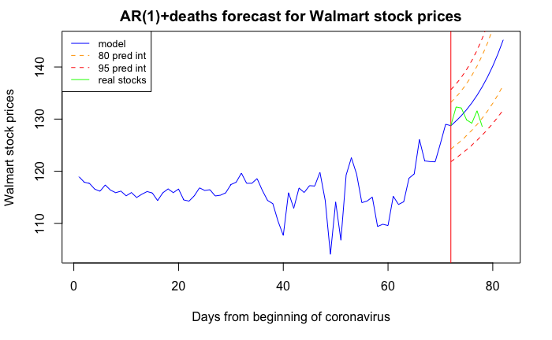

```r
lines(x=c(72:78),y=wmt_new, col = "green")
legend("topleft", legend=c("model", "80 pred int", "95 pred int", "real stocks"),
       col=c("blue", "orange","red", "green"), lty = c(1,2,2,1), cex=0.8)
```

```r
summary(ar_wmt1)
```

```
Time series regression with "numeric" data:
Start = 1, End = 71

Call:
dynlm(formula = wmt_level ~ wmt_lags + deaths_lags)

Residuals:
     Min       1Q   Median       3Q      Max
-10.9454  -0.9645   0.3321   1.4795   7.8143

Coefficients:
             Estimate Std. Error t value Pr(>|t|)
(Intercept) 5.984e+01  1.241e+01   4.821 8.37e-06 ***
wmt_lags    4.798e-01  1.076e-01   4.459 3.17e-05 ***
deaths_lags 5.891e-05  1.684e-05   3.498 0.000831 ***
---
Signif. codes:  0 ‘***’ 0.001 ‘**’ 0.01 ‘*’ 0.05 ‘.’ 0.1 ‘ ’ 1

Residual standard error: 2.983 on 68 degrees of freedom
Multiple R-squared:  0.4567,    Adjusted R-squared:  0.4407
F-statistic: 28.58 on 2 and 68 DF,  p-value: 9.809e-10
```

```r
print(future_w_d)
```

|  | Point Forecast | Lo 80 | Hi 80 | Lo 95 | Hi 95 |
| --- | --- | --- | --- | --- | --- |
| 1 | 128.7352 | 124.2559 | 133.2145 | 121.8284 | 135.6421 |
| 2 | 129.6393 | 125.0345 | 134.2441 | 122.5390 | 136.7396 |
| 3 | 130.6589 | 125.8884 | 135.4294 | 123.3031 | 138.0147 |
| 4 | 131.8087 | 126.8237 | 136.7938 | 124.1220 | 139.4954 |
| 5 | 133.1055 | 127.8475 | 138.3634 | 124.9980 | 141.2129 |
| 6 | 134.5679 | 128.9687 | 140.1670 | 125.9343 | 143.2015 |
| 7 | 136.2171 | 130.1979 | 142.2363 | 126.9359 | 145.4984 |
| 8 | 138.0771 | 131.5481 | 144.6061 | 128.0097 | 148.1444 |
| 9 | 140.1746 | 133.0347 | 147.3145 | 129.1653 | 151.1839 |
| 10 | 142.5402 | 134.6763 | 150.4040 | 130.4145 | 154.6658 |

[output cut: 1 more lines]

Model 3 wmt_level=B_0+B_1wmt_lags+B_2deaths_lags+B_3atvi_lags+B_4nflx_lags+B_5dpz_lags+E

```r
ar_wmt2 <- dynlm(wmt_level ~ wmt_lags+deaths_lags+atvi_lags+nflx_lags+dpz_lags)
future_w_d_2<-forecast(ar_wmt2, newdata=data.frame(wmt_lags=wmt[72], deaths_lags=c(deaths[72],f_d$mean), atvi_lags=c(atvi[72],future_a_d$mean[1:10]), nflx_lags=c(nflx[72],future_n_d$mean[1:10]), dpz_lags=c(dpz[72],future_d_d$mean[1:10])))
plot(x = c(1:82),y=c(future_w_d_2$x,future_w_d_2$mean),type = 'l', main="+other stock prices for Walmart stock prices", xlab="Days from beginning of coronavirus", ylab="Walmart stock prices", col="purple")
lines(x=c(72:82),y=future_w_d_2$upper[,1], col = "orange", lty=2)
```

```r
lines(x=c(72:82),y=future_w_d_2$lower[,1], col = "orange", lty=2)
lines(x=c(72:82),y=future_w_d_2$upper[,2], col = "red", lty=2)
```

```r
lines(x=c(72:82),y=future_w_d_2$lower[,2], col = "red", lty=2)
abline(v=72, col='red')
```

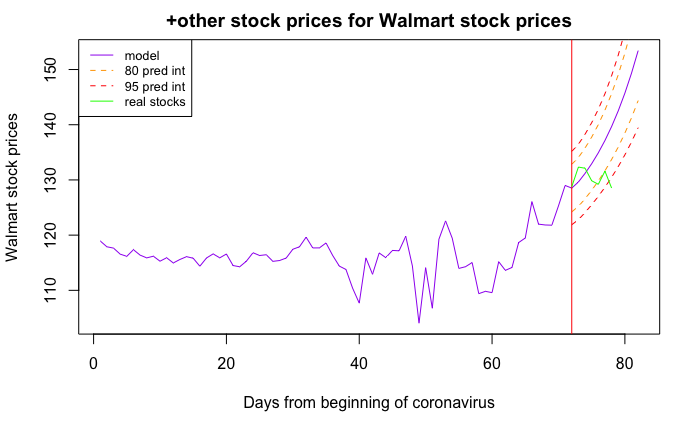

```r
lines(x=c(72:78),y=wmt_new, col = "green")
legend("topleft", legend=c("model", "80 pred int", "95 pred int", "real stocks"),
       col=c("purple", "orange","red", "green"), lty = c(1,2,2,1), cex=0.8)
```

```r
summary(ar_wmt2)
```

```
Time series regression with "numeric" data:
Start = 1, End = 71

Call:
dynlm(formula = wmt_level ~ wmt_lags + deaths_lags + atvi_lags +
    nflx_lags + dpz_lags)

Residuals:
     Min       1Q   Median       3Q      Max
-10.4258  -1.3383   0.0038   1.2132   6.2075

Coefficients:
              Estimate Std. Error t value Pr(>|t|)
(Intercept)  7.823e+01  1.355e+01   5.774 2.36e-07 ***
wmt_lags     3.333e-01  1.250e-01   2.666  0.00968 **
deaths_lags  9.350e-05  1.953e-05   4.787 1.01e-05 ***
atvi_lags    3.149e-01  2.098e-01   1.501  0.13824
nflx_lags   -3.135e-02  2.562e-02  -1.223  0.22563
dpz_lags    -3.008e-02  1.439e-02  -2.090  0.04051 *
---
Signif. codes:  0 ‘***’ 0.001 ‘**’ 0.01 ‘*’ 0.05 ‘.’ 0.1 ‘ ’ 1

Residual standard error: 2.839 on 65 degrees of freedom
Multiple R-squared:  0.5296,    Adjusted R-squared:  0.4934
F-statistic: 14.63 on 5 and 65 DF,  p-value: 1.341e-09
```

```r
print(future_w_d_2)
```

|  | Point Forecast | Lo 80 | Hi 80 | Lo 95 | Hi 95 |
| --- | --- | --- | --- | --- | --- |
| 1 | 128.5230 | 124.2199 | 132.8261 | 121.8853 | 135.1607 |
| 2 | 129.6241 | 125.1929 | 134.0553 | 122.7889 | 136.4594 |
| 3 | 131.1790 | 126.5838 | 135.7742 | 124.0907 | 138.2673 |
| 4 | 132.9336 | 128.1147 | 137.7525 | 125.5003 | 140.3669 |
| 5 | 134.9135 | 129.7996 | 140.0273 | 127.0252 | 142.8017 |
| 6 | 137.1475 | 131.6556 | 142.6395 | 128.6760 | 145.6191 |
| 7 | 139.6685 | 133.7032 | 145.6337 | 130.4669 | 148.8700 |
| 8 | 142.5130 | 135.9675 | 149.0585 | 132.4163 | 152.6097 |
| 9 | 145.7226 | 138.4777 | 152.9675 | 134.5471 | 156.8981 |
| 10 | 149.3441 | 141.2683 | 157.4200 | 136.8868 | 161.8014 |

[output cut: 1 more lines]

Step 4. Checking accuracy of forecasts of all models

```r
nflx_fit<-data.frame(accuracy(f_nf, nflx_new)[2,1:6],accuracy(future_n_d, nflx_new)[2,1:6],accuracy(future_n_d_2, nflx_new)[2,1:6])
colnames(nflx_fit)<-c("NFLX AR(1)", "NFLX AR+deaths", "NFLX AR+deaths+stocks")
print(nflx_fit)
```

|  | NFLX AR(1) | NFLX AR+deaths | NFLX AR+deaths+stocks |
| --- | --- | --- | --- |
| ME | 36.984421 | 1.6206326 | 2.0179094 |
| RMSE | 38.148505 | 10.5460351 | 11.2270356 |
| MAE | 36.984421 | 9.1756670 | 9.6959508 |
| MPE | 8.591323 | 0.3473372 | 0.4390547 |
| MAPE | 8.591323 | 2.1297059 | 2.2500830 |
| MASE | 3.959908 | 0.4959708 | 0.5240937 |

```r
dpz_fit<-data.frame(accuracy(f_dpz, dpz_new)[2,1:6],accuracy(future_d_d, dpz_new)[2,1:6],accuracy(future_d_d_2, dpz_new)[2,1:6])
colnames(dpz_fit)<-c("DPZ AR(1)", "DPZ AR+deaths", "DPZ AR+deaths+stocks")
print(dpz_fit)
```

[output not shown]

```r
atvi_fit<-data.frame(accuracy(f_a, atvi_new)[2,1:6],accuracy(future_a_d, atvi_new)[2,1:6],accuracy(future_a_d_2, atvi_new)[2,1:6])
colnames(atvi_fit)<-c("ATVI AR(1)", "ATVI AR+deaths", "ATVI AR+deaths+stocks")
print(atvi_fit)
```

|  | ATVI AR(1) | ATVI AR+deaths | ATVI AR+deaths+stocks |
| --- | --- | --- | --- |
| ME | 5.593842 | 2.611065 | 2.060253 |
| RMSE | 5.683410 | 2.793203 | 2.459967 |
| MAE | 5.593842 | 2.611065 | 2.078510 |
| MPE | 8.396789 | 3.909019 | 3.079167 |
| MAPE | 8.396789 | 3.909019 | 3.106880 |
| MASE | 3.925309 | 1.353308 | 1.077286 |

```r
wmt_fit<-data.frame(accuracy(f_w, wmt_new)[2,1:6],accuracy(future_w_d, wmt_new)[2,1:6],accuracy(future_w_d_2, wmt_new)[2,1:6])
colnames(wmt_fit)<-c("WMT AR(1)", "WMT AR+deaths", "WMT AR+deaths+stocks")
print(wmt_fit)
```

|  | WMT AR(1) | WMT AR+deaths | WMT AR+deaths+stocks |
| --- | --- | --- | --- |
| ME | 10.728128 | -1.763227 | -3.085597 |
| RMSE | 11.108355 | 3.709952 | 5.414961 |
| MAE | 10.728128 | 2.956541 | 4.195267 |
| MPE | 8.219287 | -1.372658 | -2.391023 |
| MAPE | 8.219287 | 2.275079 | 3.231328 |
| MASE | 4.897115 | 1.125637 | 1.597254 |